# OTX2 case study — Fig 3c

Paper: Wang et al. *Nat. Genet.* **57**, 2772-2784 (2025) 10.1038/s41588-025-02350-8

> **Upstream / preprocessing.** FASTQ → BAM → bigwig, MACS2 peak calling, Xia 2019 / Zou 2022 / Gifford 2013 downloads, and the one-off xlsx → TSV extractions are all documented in `preprocess.ipynb`. This notebook starts from the cached inputs under `/scratch/users/steorra/data/otx2/`.

## 1 · Setup

```python
import os, pathlib, warnings
os.environ['PATH'] = '/scratch/users/steorra/env/omicdev/bin:' + os.environ.get('PATH', '')
warnings.filterwarnings('ignore', category=UserWarning)

import numpy as np
import pandas as pd
import matplotlib.pyplot as plt

import epione as epi
epi.pl.plot_set()

DATA        = pathlib.Path('/scratch/users/steorra/data/otx2')
OMIX        = DATA / 'OMIX006476'
ZOU         = DATA / 'GSE197265'
SUPP_DIR    = DATA / 'supp'
GENCODE_GTF = pathlib.Path('/scratch/users/steorra/data/hg19/gencode.v41lift37.annotation.gtf.gz')
```

[output not shown]

## 2 · Load gene lists (from cached TSVs — no xlsx / SUPP_TABLES needed)

The two gene sets are now derived from public data:

```python
# 4C-activated: genes derived from Zou 2022 stage bigwigs
activated_4c = set(pd.read_csv(SUPP_DIR/'4C_activated_from_zou2022.tsv',
                               sep='\t')['gene'].astype(str))

# Nonmaternal: D2-expressed (S4 gene list) minus activated
s4 = pd.read_csv(SUPP_DIR/'S4_OTX2_KD_RNA_count.tsv', sep='\t')
d2_expressed = set(s4['gene'].dropna().astype(str).str.strip()) - {'nan',''}
nonmaternal = d2_expressed - activated_4c

print(f'4C activated: {len(activated_4c)}   Nonmaternal: {len(nonmaternal)}')
```

```
4C activated: 372   Nonmaternal: 27811
```

## 3 · Build gene-subset tables from GENCODE

Two gene sets → two GTF slices. `compute_matrix_region(anchor='5p')` does the strand-aware TSS anchoring internally (start on `+`, end on `-`). No manual coordinate collapsing needed.

```python
# Filter GENCODE to protein-coding genes (one row per gene), drop
# unplaced contigs, and slice to the two gene sets. compute_matrix_region
# takes the raw GTF slice — no schema juggling needed (chrom/seqname
# are interchangeable, gene_id auto-derived from gene_name).
gtf = epi.utils.get_gene_annotation(str(GENCODE_GTF))  # protein_coding, no chrM
gtf = gtf[~gtf['chrom'].str.contains('_')].drop_duplicates('gene_name').copy()
gtf = gtf.rename(columns={'gene_name':'gene_id'})

tgt_gtf = gtf[gtf['gene_id'].isin(activated_4c)].reset_index(drop=True)
non_gtf = gtf[gtf['gene_id'].isin(nonmaternal)].reset_index(drop=True)
print(f'resolved TSSs: targets={len(tgt_gtf)}  nontargets={len(non_gtf)}')
```

```
resolved TSSs: targets=372  nontargets=18566
```

## 4 · Compute TSS-centred signal matrices

`bigwig.compute_matrix_region` returns an AnnData per gene set; rows are genes, columns are 60 bins spanning ±3 kb around the TSS. Bins of − strand genes are reversed so column 0 is always 5′ of the TSS.

```python
BW = str(OMIX / 'h_OTX2_day2_CUTRUN_rep12_pmu_100bp_rpkm_bamCoverage.bw')
bw = epi.bulk.bigwig({'OTX2 4C': BW}); bw.read()

ad_tgt = bw.compute_matrix_region('OTX2 4C', tgt_gtf, nbins=60, upstream=3000, downstream=3000, anchor='5p')
ad_non = bw.compute_matrix_region('OTX2 4C', non_gtf, nbins=60, upstream=3000, downstream=3000, anchor='5p')
print(ad_tgt.shape, ad_non.shape)
```

```
└─ Load bigWig files
  └─ Loading OTX2 4C...
  └─ Computing OTX2 4C matrix (anchors=['5p'])
```

```
  └─ OTX2 4C matrix finished
  └─ Computing OTX2 4C matrix (anchors=['5p'])
```

```
  └─ OTX2 4C matrix finished
(372, 60) (18566, 60)
```

## 5 · Overlay the two mean-signal curves

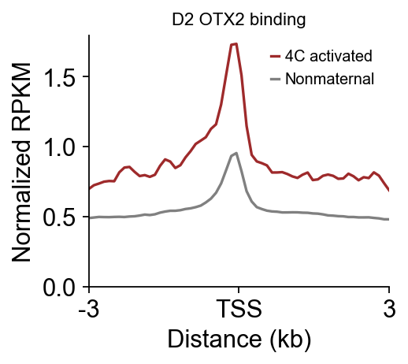

```python
fig, ax = bw.plot_matrix_line_compare(
    'OTX2 4C',
    groups={'4C activated': ad_tgt, 'Nonmaternal': ad_non},
    colors={'4C activated': '#9E2A2B', 'Nonmaternal': '#808080'},
    title='D2 OTX2 binding',
    clip_percentile=99, normalize='flanks', normalize_ref='Nonmaternal',
    flank_kb=1.5, flank_target=0.5,
)
ax.set_xticks([-3, 0, 3]); ax.set_xticklabels(['-3', 'TSS', '3'])
plt.show()
```